# ggplot2 Themes: Fundamentals, Structure & Custom Creation

A Comprehensive Guide with Working Examples

Cheng Peng

West Chester University

# 1 Theme Fundamentals

ggplot2’s theming system is a comprehensive framework that controls every non-data visual aspect of your plots. Themes handle backgrounds, grids, text formatting, legends, and faceting strips—essentially everything that makes your plot look polished and publication-ready.

**Key Concept:** Themes in ggplot2 follow a strict hierarchical inheritance structure. When you modify a theme element, you’re overriding the default values from the complete theme you started with.

## 1.1 Complete vs. Incomplete Themes

A complete theme specifies every visual property of a plot. These are designed to be standalone.

**Examples**:

- `theme_grey()` (default)
- `theme_bw()`
- `theme_minimal()`
- `theme_classic()`
- `theme_void()`

**Behavior**: When you add `+ theme(...)` to a complete theme, ggplot merges your changes with the existing complete specification.

An incomplete theme (created with `theme()`) specifies only some properties, leaving others to be inherited from the current complete theme.

**Example**:

```r
my_incomplete <- theme(axis.text.x = element_text(angle = 45))
```

The following example contains workable code:

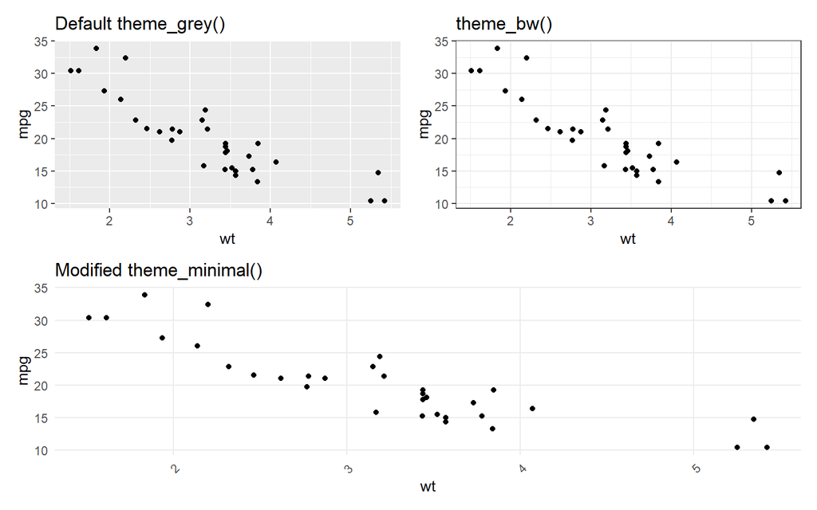

```r
# Default theme (complete)
p_default <- ggplot(mtcars, aes(wt, mpg)) +
  geom_point() +
  labs(title = "Default theme_grey()")

# Built-in complete theme
p_bw <- ggplot(mtcars, aes(wt, mpg)) +
  geom_point() +
  theme_bw() +
  labs(title = "theme_bw()")

# Incomplete theme modification
p_modified <- ggplot(mtcars, aes(wt, mpg)) +
  geom_point() +
  theme_minimal() +
  theme(
    axis.text.x = element_text(angle = 45, hjust = 1),
    panel.grid.minor = element_blank()
  ) +
  labs(title = "Modified theme_minimal()")

# Display comparison
(p_default + p_bw) / p_modified
```

The following two operators `%+replace%` and `+` are used in building complete and incomplete themes in `ggplot()`.

## 1.2 `%+replace%` vs `+`

`%+replace%` – Use when you are building a completely custom theme from scratch (e.g., starting with theme() or theme_minimal() and wanting to replace entire element structures rather than merging).

`+` – Use for incremental changes to an existing theme (e.g., starting with theme_bw() then modifying only axis text size).

**Example**: Using %+replace% (complete custom theme)

```r
#library(ggplot2)

my_custom_theme <- theme_minimal() %+replace%
  theme(
    axis.title = element_text(color = "red", size = 20),
    axis.text = element_text(color = "blue", size = 12),
    # explicitly not inheriting from previous theme defaults
    panel.background = element_rect(fill = "lightgray")
  )
```

Here, `%+replace%` replaces the entire `axis.title`, `axis.text`, and `panel.background` specifications instead of merging with the existing `theme_minimal()` defaults.

**Example**: Using `+` (incremental modification)

```r
modified_theme <- theme_bw() +
  theme(
    axis.title.x = element_text(color = "red"),  # keeps other axis.title.y default
    plot.title = element_text(hjust = 0.5)
  )
```

Here, only the specified changes are added; all other theme elements from `theme_bw()` remain unchanged.

**Best Practices**

| Scenario | Recommended Operator |
| --- | --- |
| Start with complete theme, tweak a few things | `+` |
| Build completely custom theme from scratch | `theme_void() %+replace% theme(...)` |
| Modify incomplete theme | Almost always + (never `%+replace%` unless you know you want to purge defaults) |
| Remove a specific element set | `%+replace%` with `element_blank()` |

**Pro Tip:** Use `%+replace%` when creating a complete custom theme from scratch. Use `+` for incremental modifications to an existing theme.

# 2 The Hierarchy of GGPlot Elements

The ggplot and theme have a complex structure. Two hierarchical structures are useful in design and debugging. The component hierarchy diagram answers “what parts exist?” for customization, while the pipeline diagram answers “what happens when?” for understanding rendering order.

## 2.1 Processing pipeline

The rendering pipeline diagram (or grammar of graphics evaluation order). It outlines the dynamic processing flow, sequencing from geoms to aesthetics, scales, coordinate systems, facets, statistical transforms, and finally themes.

**1. Geoms (Highest Priority)**: Layer-specific visual elements that override everything below

```
geom_point(color = "red", size = 3)           # Specific to this layer
geom_line(linetype = "dashed")                # Overrides any global settings
```

**2. Aesthetics Mapping (aes())**: Mapped variables override constants; scales transform these

```
aes(x = mpg, y = wt, color = cyl)             # Mapped to data
aes(x = mpg, y = wt, color = "blue")          # Treated as constant, NOT mapping
```

**3. Scales**: Transform and guide the visual representation of mapped aesthetics

```
scale_color_gradient(low = "blue", high = "red")  # Overrides default color scale
scale_x_log10()                                   # Transforms axis
```

**4. Coordinate Systems (coord_xx())**: Override axis and coordinate properties set by scales

```
coord_flip()                      # Swaps x and y axes
coord_cartesian(xlim = c(0, 10))  # Zooms (doesn't drop data)
```

**5. Facets (facet_xx())**: Split data into subplots; each facet inherits from global settings but can have its own scale

```
facet_wrap(~cyl, scales = "free")   # Different axis scales per facet
```

**6. Statistical Transformations (stat_xx())**: Override default statistical calculations

```
stat_smooth(method = "lm")           # Uses linear model instead of loess
stat_bin(bins = 30)                  # Overrides default binning
```

**7. Themes (Lowest Priority)**: Control non-data ink: backgrounds, grids, text, legends (not data representation)

```
theme_bw() +                          # Complete theme
  theme(axis.text = element_text(size = 10))  # Specific element
```

## 2.2 ggplot2 Component hierarchy

The component hierarchy tree (or plot anatomy diagram). It illustrates the static, nested structure of a plot, showing how elements like the panel, axes, legend, strip, and titles branch into specific sub-components such as backgrounds, borders, grids, ticks, and text.

```
 plot
 ├── panel
 │   ├── background
 │   ├── border
 │   ├── grid
 │   │   ├── major
 │   │   └── minor
 │   └── spacing
 ├── axis
 │   ├── title (x, y, top, right)
 │   ├── text (x, y, top, right)
 │   ├── ticks (x, y, top, right)
 │   └── line (x, y, top, right)
 ├── legend
 │   ├── background
 │   ├── title
 │   ├── text
 │   └── key
 ├── strip
 │   ├── background
 │   └── text
 └── plot
     ├── title
     ├── subtitle
     ├── caption
     └── tag
```

# 3 The Four Element Functions

The four element functions in ggplot2 are `element_blank()`, `element_rect()`, `element_line()`, and `element_text()` . These functions are the building blocks of the ggplot2 theme system, used to control the appearance of all non-data components of a plot .

- `element_blank()` – Draws nothing and allocates no space; effectively removes a theme element .
- `element_rect()` – Used for rectangular areas such as plot backgrounds, panel borders, and legend backgrounds .
- `element_line()` – Used for lines including axis lines, grid lines, and tick marks .
- `element_text()` – Used for text elements like plot titles, axis labels, legend text, and strip text .

Each function accepts specific parameters. For instance, `element_text()` supports `family`, `face`, `colour`, `size`, `hjust`, `vjust`, `angle`, and `lineheight` , while `element_rect()` accepts `fill`, `colour`, `linewidth`, and `linetype`.

Additional element types exist, such as `element_polygon()` and `element_point()`, but are not widely used .

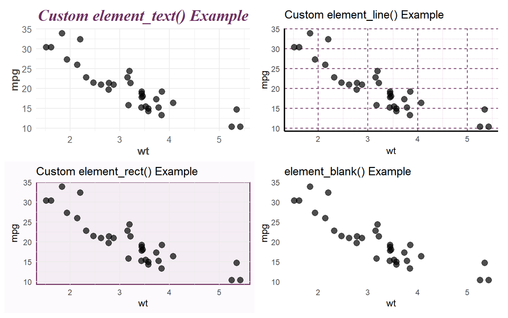

```r
# Create a base plot for demonstration
base_plot <- ggplot(mtcars, aes(wt, mpg)) +
  geom_point(size = 3, alpha = 0.7)

# 1. element_text() - for all text elements
p_text <- base_plot +
  theme_minimal() +
  theme(
    plot.title = element_text(
      family = "serif",
      face = "bold.italic",
      colour = "#6E3061",
      size = 18,
      hjust = 0.5
    ),
    axis.title = element_text(
      face = "bold",
      colour = "grey30",
      size = 12
    ),
    axis.text = element_text(
      colour = "grey40",
      size = 10
    )
  ) +
  labs(title = "Custom element_text() Example")

# 2. element_line() - for lines and borders
p_line <- base_plot +
  theme_minimal() +
  theme(
    panel.grid.major = element_line(
      colour = "#6E3061",
      linewidth = 0.5,
      linetype = "dashed"
    ),
    panel.grid.minor = element_line(
      colour = "#c49bb8",
      linewidth = 0.2,
      linetype = "dotted"
    ),
    axis.line = element_line(
      colour = "black",
      linewidth = 0.8
    )
  ) +
  labs(title = "Custom element_line() Example")

# 3. element_rect() - for rectangles and backgrounds
p_rect <- base_plot +
  theme_minimal() +
  theme(
    panel.background = element_rect(
      fill = "#f4edf3",
      colour = "#6E3061",
      linewidth = 1
    ),
    plot.background = element_rect(
      fill = "#fdfafd",
      colour = NA
    ),
    legend.background = element_rect(
      fill = "white",
      colour = "#d4c0d1"
    )
  ) +
  labs(title = "Custom element_rect() Example")

# 4. element_blank() - to remove elements
p_blank <- base_plot +
  theme_minimal() +
  theme(
    panel.grid = element_blank(),
    axis.ticks = element_blank(),
    legend.position = "none"
  ) +
  labs(title = "element_blank() Example")

# Display all four
(p_text + p_line) / (p_rect + p_blank)
```

## 3.1 `element_text()` Parameter Reference

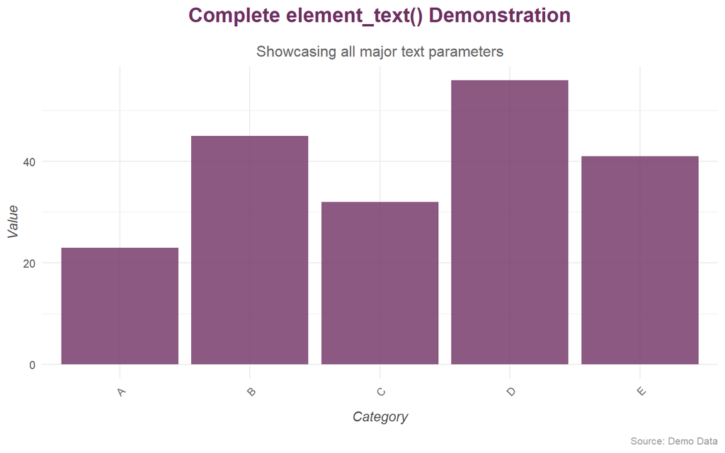

```r
# Demonstrate key element_text parameters
demo_data <- data.frame(
  category = LETTERS[1:5],
  value = c(23, 45, 32, 56, 41)
)

ggplot(demo_data, aes(category, value)) +
  geom_col(fill = "#6E3061", alpha = 0.8) +
  theme_minimal() +
  theme(
    # Title with multiple parameters
    plot.title = element_text(
      family = "sans",
      face = "bold",
      colour = "#6E3061",
      size = 16,
      hjust = 0.5,
      margin = margin(b = 15)
    ),
    # Subtitle
    plot.subtitle = element_text(
      size = 12,
      colour = "grey40",
      hjust = 0.5
    ),
    # Axis titles
    axis.title.x = element_text(
      face = "italic",
      colour = "grey30",
      margin = margin(t = 10)
    ),
    axis.title.y = element_text(
      angle = 90,
      face = "italic",
      colour = "grey30"
    ),
    # Rotated axis text
    axis.text.x = element_text(
      angle = 45,
      hjust = 1,
      colour = "grey40"
    ),
    # Caption
    plot.caption = element_text(
      size = 8,
      colour = "grey60",
      hjust = 1,
      margin = margin(t = 10)
    )
  ) +
  labs(
    title = "Complete element_text() Demonstration",
    subtitle = "Showcasing all major text parameters",
    x = "Category",
    y = "Value",
    caption = "Source: Demo Data"
  )
```

Some of the graphical parameters used in the above plots are summarizedin the following table:

| Parameter | Description | Example Values |
| --- | --- | --- |
| `family` | Font family name | `“sans”`, `“serif”`, `“mono”` |
| `face` | Font face/style | `“plain”`, `“italic”`, `“bold”`, `“bold.italic”` |
| `colour` | Text color | `“#6E3061”`, `“grey40”`, `“steelblue”` |
| `size` | Font size in pts | `12`, `rel(0.9)`, `rel(1.2)` |
| `hjust` | Horizontal justification | `0` (left), `0.5` (center), `1` (right) |
| `vjust` | Vertical justification | `0` (bottom), `0.5` (middle), `1` (top) |
| `angle` | Rotation angle | `0`, `45`, `90` |
| `lineheight` | Line height multiplier | `1`, `1.5` |
| `margin` | Margin around text | `margin(t=10, r=5, b=10, l=5)` |

## 3.2 `element_rect()` Parameter Reference

`element_rect()` controls the appearance of rectangular elements: backgrounds (plot, panel, legend, strip), borders, and keys.

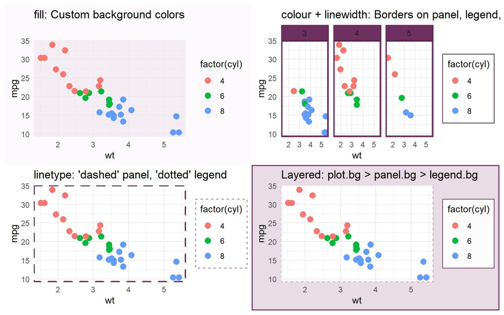

```r
# Create a dedicated rectangle demonstration
rect_demo <- ggplot(mtcars, aes(wt, mpg, colour = factor(cyl))) +
  geom_point(size = 3)

# 1. fill: Interior color of rectangles
p_fill <- rect_demo +
  theme_minimal() +
  theme(
    # Panel background fill
    panel.background = element_rect(
      fill = "#f4edf3",        # Light purple tint
      colour = NA               # No border
    ),
    # Plot background fill
    plot.background = element_rect(
      fill = "#fdfafd",        # Very light purple
      colour = NA
    ),
    # Legend key fill
    legend.key = element_rect(
      fill = "#faf5f9",        # Match panel
      colour = NA
    )
  ) +
  labs(title = "fill: Custom background colors")

# 2. colour & linewidth: Borders on rectangles
p_border <- rect_demo +
  theme_minimal() +
  theme(
    # Panel border with color and width
    panel.border = element_rect(
      fill = NA,                # Transparent interior
      colour = "#6E3061",      # Purple border
      linewidth = 1.5          # Thick border
    ),
    # Legend background with border
    legend.background = element_rect(
      fill = "white",
      colour = "#4a2040",      # Dark purple border
      linewidth = 0.5
    ),
    # Strip background with fill AND border
    strip.background = element_rect(
      fill = "#6E3061",        # Purple fill
      colour = "#4a2040",      # Darker border
      linewidth = 0.5
    )
  ) +
  facet_wrap(~ gear) +
  labs(title = "colour + linewidth: Borders on panel, legend, strip")

# 3. linetype: Border pattern for rectangles
p_linetype <- rect_demo +
  theme_minimal() +
  theme(
    panel.border = element_rect(
      fill = NA,
      colour = "#6E3061",
      linewidth = 1.2,
      linetype = "dashed"      # Dashed border
    ),
    legend.background = element_rect(
      fill = "white",
      colour = "#c49bb8",
      linewidth = 0.8,
      linetype = "dotted"      # Dotted border
    )
  ) +
  labs(title = "linetype: 'dashed' panel, 'dotted' legend")

# 4. Multiple layered rectangles
p_layered <- rect_demo +
  theme_minimal() +
  theme(
    # Outer plot background
    plot.background = element_rect(
      fill = "#e8dce5",        # Medium purple
      colour = "#6E3061",
      linewidth = 1
    ),
    # Inner panel background
    panel.background = element_rect(
      fill = "white",
      colour = "#c49bb8",
      linewidth = 0.5,
      linetype = "dashed"
    ),
    # Legend sits on top
    legend.background = element_rect(
      fill = alpha("white", 0.9),  # Semi-transparent white
      colour = "#6E3061",
      linewidth = 0.5
    )
  ) +
  labs(title = "Layered: plot.bg > panel.bg > legend.bg")

# Display rectangle demonstrations
(p_fill + p_border) / (p_linetype + p_layered)
```

Some of the key graphical parameters used in the above example of `element_redt()` are summarized in the following table.

| Parameter | Type | Default | Description Example |
| --- | --- | --- | --- |
| `fill` | character | `NULL` | Interior fill color |
| `colour` / `color` | character | `NULL` | Border color |
| `linewidth` | numeric | `NULL` | Border width in mm |
| `linetype` | character/numeric | `NULL` | Border line pattern |
| `inherit.blank` | logical | `FALSE` | Inherit blank from parent? |

**Key Pattern:** Use `fill = NA` when you want a transparent interior with only a visible border. Use

[output not shown]

when you want a filled rectangle with no border.

## 3.3 `element_line()` Parameter Reference

`element_line()` controls the appearance of all line elements: grid lines, axis lines, tick marks, panel borders, and more.

**Syntax**

```
element_line(
  colour = NULL,       # Line color (color also accepted)
  linewidth = NULL,    # Line width in mm (replaces deprecated 'size')
  linetype = NULL,     # Line type: "solid", "dashed", "dotted", "dotdash",
                       # "longdash", "twodash", "blank"
  lineend = NULL,      # Line end style: "round", "butt", "square"
  arrow = NULL,        # Add arrow to line end (use arrow() function)
  inherit.blank = FALSE # Should blank lines inherit from parents?
)
```

**Example**

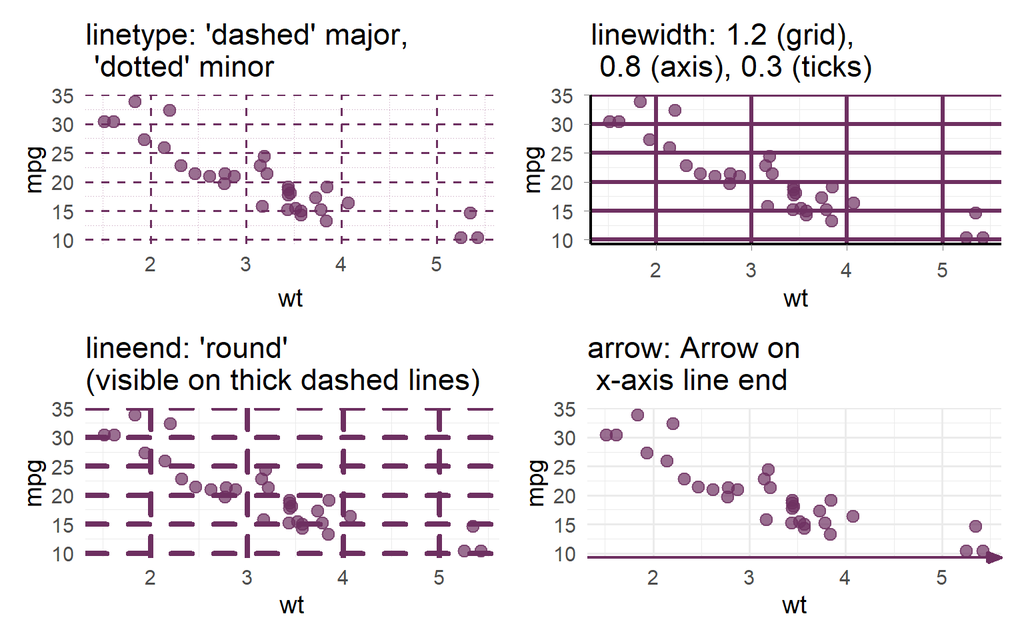

```r
# Create a dedicated line demonstration
line_demo <- ggplot(mtcars, aes(wt, mpg)) +
  geom_point(size = 3, alpha = 0.7, colour = "#6E3061") +
  theme_minimal(base_size = 14)

# 1. linetype: Different line patterns
p_linetype <- line_demo +
  theme(
    panel.grid.major = element_line(
      colour = "#6E3061",
      linewidth = 0.6,
      linetype = "dashed"    # Try: solid, dashed, dotted, dotdash, longdash, twodash
    ),
    panel.grid.minor = element_line(
      colour = "#c49bb8",
      linewidth = 0.3,
      linetype = "dotted"
    )
  ) +
  labs(title = "linetype: 'dashed' major,\n 'dotted' minor")

# 2. linewidth: Controlling line thickness
p_linewidth <- line_demo +
  theme(
    panel.grid.major = element_line(
      colour = "#6E3061",
      linewidth = 1.2,       # Thicker lines
      linetype = "solid"
    ),
    axis.line = element_line(
      colour = "black",
      linewidth = 0.8        # Medium axis lines
    ),
    axis.ticks = element_line(
      colour = "grey50",
      linewidth = 0.3        # Thin ticks
    )
  ) +
  labs(title = "linewidth: 1.2 (grid), \n 0.8 (axis), 0.3 (ticks)")

# 3. lineend: How line ends are rendered
p_lineend <- line_demo +
  theme(
    panel.grid.major = element_line(
      colour = "#6E3061",
      linewidth = 1.5,
      linetype = "dashed",
      lineend = "round"      # Try: "round", "butt", "square"
    )
  ) +
  labs(title = "lineend: 'round' \n(visible on thick dashed lines)")

# 4. arrow: Adding arrows to lines
p_arrow <- line_demo +
  theme(
    axis.line.x = element_line(
      colour = "#6E3061",
      linewidth = 0.8,
      arrow = arrow(
        angle = 20,          # Arrowhead angle
        length = unit(0.3, "cm"),  # Arrowhead size
        ends = "last",       # "first", "last", "both"
        type = "closed"      # "open" or "closed"
      )
    )
  ) +
  labs(title = "arrow: Arrow on \n x-axis line end")

# Display line demonstrations
(p_linetype + p_linewidth) / (p_lineend + p_arrow)
```

Some graphical parameters used in the above example of `element_line()` is summarized in the following table.

| Parameter | Type | Default | Description Example |
| --- | --- | --- | --- |
| `colour` / `color` | character | `NULL` | Line color |
| `linewidth` | numeric | `NULL` | Line width in mm |
| `linetype` | character/numeric | `NULL` | Line pattern |
| `lineend` | character | `NULL` | Line cap style |
| `arrow` | arrow object | `NULL` | Arrow specification |
| `inherit.blank` | `FALSE` | Inherit blank from parent? | `TRUE`, `FALSE` |

**Note on linewidth vs size:** In ggplot2 ≥ 3.4.0, `linewidth` replaced the deprecated `size` parameter for line elements. Always use `linewidth` for lines, `size` for points/text.

## 3.4 `element_blank()` Parameter Reference

`element_blank()` is the simplest yet most powerful element function. It removes a theme element entirely, as if it were never drawn.

**Syntax**

```
element_blank()
```

**Working Example**

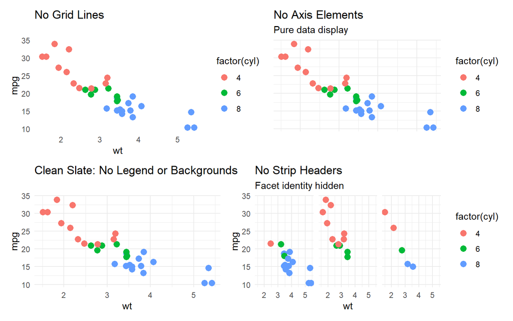

```r
base_for_blank <- ggplot(mtcars, aes(wt, mpg, colour = factor(cyl))) +
  geom_point(size = 3)

# 1. Remove all grid lines
p_no_grid <- base_for_blank +
  theme_minimal() +
  theme(
    panel.grid.major = element_blank(),
    panel.grid.minor = element_blank()
  ) +
  labs(title = "No Grid Lines")

# 2. Remove axis elements (minimalist look)
p_no_axis <- base_for_blank +
  theme_minimal() +
  theme(
    axis.line = element_blank(),
    axis.ticks = element_blank(),
    axis.text = element_blank(),
    axis.title = element_blank()
  ) +
  labs(title = "No Axis Elements", subtitle = "Pure data display")

# 3. Remove legend and background elements
p_clean <- base_for_blank +
  theme_minimal() +
  theme(
    legend.position = "none",         # Remove entire legend
    legend.background = element_blank(),
    panel.background = element_blank(),
    plot.background = element_blank(),
    panel.border = element_blank()
  ) +
  labs(title = "Clean Slate: No Legend or Backgrounds")

# 4. Remove strip elements (for faceted plots)
p_no_strips <- base_for_blank +
  facet_wrap(~ gear) +
  theme_minimal() +
  theme(
    strip.background = element_blank(),
    strip.text = element_blank()
  ) +
  labs(title = "No Strip Headers", subtitle = "Facet identity hidden")

# Display blank demonstrations
(p_no_grid + p_no_axis) / (p_clean + p_no_strips)
```

`element_blank()` Common Usage Table

| Theme Element to Blank | Effect | Common Use Case |
| --- | --- | --- |
| panel.grid.major | Removes major grid lines | Clean, minimalist plots |
| panel.grid.minor | Removes minor grid lines | Reduce visual clutter |
| panel.grid | Removes ALL grid lines | Complete grid removal |
| axis.ticks | Removes tick marks | Modern, streamlined look |
| axis.text | Removes tick labels | When labels aren’t needed |
| axis.title | Removes axis titles | When axes are self-explanatory |
| axis.line | Removes axis lines | Combine with void theme |
| legend.title | Removes legend title | When legend is self-explanatory |
| legend.key | Removes legend key background | Transparent legend symbols |
| strip.background | Removes facet strip background | Minimalist faceting |
| strip.text | Removes facet labels | Hide facet identity |
| panel.background | Removes panel fill | Transparent plotting area |
| plot.background | Removes plot fill | Transparent overall background |
| panel.border | Removes panel border | No framing rectangle |

**Important:** `element_blank()` completely removes an element. For legends, use

[output not shown]

instead of blanking all legend sub-elements individually.

## 3.5 Overall Summary: Key Graphical Parameters

Below is a comprehensive cross-reference table of all key graphical parameters used across the four element functions. Use this as your quick reference when building custom themes.

| Parameter | Type | Used In | Description & Common Values |
| --- | --- | --- | --- |
| `family` | character | `element_text()` | Font family name. Common: `“sans”`, `“serif”`, `“mono”`, `“Arial”`, `“Times”` |
| `face` | character | `element_text()` | Font style: `“plain”`, `“italic”`, `“bold”`, `“bold.italic”` |
| `colour` / `color` | character | `element_text()` `element_line()` `element_rect()` | Color specification. Accepts: hex codes (`“#6E3061”`), named colors (`“steelblue”`), `NA` (transparent/no color) |
| `size` | numeric | `element_text()` | Font size in points. Use `rel()` for scaling: `12`, `rel(0.9)`, `rel(1.2)` |
| `linewidth` | numeric | `element_line()` `element_rect()` | Line/border width in mm. Common: `0.3`, `0.5`, `0.8`, `1.0`, `1.5`, `2.0` |
| `linetype` | character / numeric | `element_line()` `element_rect()` | Line pattern. Character: `“solid”`, `“dashed”`, `“dotted”`, `“dotdash”`, `“longdash”`, `“twodash”`, `“blank”`. Numeric: `1`–`6` |
| `fill` | character | `element_rect()` | Interior fill color for rectangles. Common: `“white”`, `“grey95”`, `“#f4edf3”`, `NA` (transparent) |
| `hjust` | numeric (0–1) | `element_text()` | Horizontal justification: `0` (left), `0.5` (center), `1` (right) |
| `vjust` | numeric (0–1) | `element_text()` | Vertical justification: `0` (bottom), `0.5` (middle), `1` (top) |
| `angle` | numeric | `element_text()` | Rotation angle in degrees: `0` (horizontal), `45`, `90` (vertical), `-45`, `270` |
| `lineheight` | numeric | `element_text()` | Line spacing multiplier: `1` (normal), `1.5` (loose), `0.8` (tight) |
| `margin` | margin object | `element_text()` | Space around text: `margin(t=10, r=5, b=10, l=5)`. t=top, r=right, b=bottom, l=left |
| `lineend` | character | `element_line()` | Line cap style: `“round”`, `“butt”`, `“square”`. Most visible on thick lines |
| `arrow` | arrow object | `element_line()` | Arrow specification: arrow(angle=20, length=unit(0.3,“cm”), ends=“last”, type=“closed”) |
| `debug` | logical | `element_text()` | Draw debug rectangle: `TRUE`, `FALSE` (default). Useful for layout debugging |
| `inherit.blank` | logical | `element_line()` `element_rect()` | Inherit blank from parent element: `TRUE`, `FALSE` (default). Advanced usage only |

**Quick Tip:** The `colour` parameter accepts both British (`colour`) and American (`color`) spellings. They are completely interchangeable in ggplot2.

## 3.6 `element_rect()` Reference

Core Parameters for Borders and Backgrounds

fill : The fill color for the rectangular area (e.g., the panel or plot background). Accepts color names, hex codes, or RGB values. Use fill_alpha() to set transparency .

colour / color : The border line color. color is an alias for colour .

linewidth : The border size, measured in mm . (Note: the older size parameter is deprecated for this purpose).

linetype : The border line type. Can be specified as an integer (0-8), a name (“blank”, “solid”, “dashed”, “dotted”, “dotdash”, “longdash”, “twodash”), or a hexadecimal string (e.g., “44”) .

Additional Styling Parameters linejoin : Controls how corners of the border are rendered. Options include “round”, “mitre”, or “bevel” .

inherit.blank : Logical value. If TRUE and a parent element is element_blank(), this element will also be blank. If FALSE, it ignores blank parents .

Deprecated Parameter size : This parameter is deprecated. Use linewidth for border thickness or fontsize for text-related sizing instead .

Usage Tip: This function is most commonly used within theme() to modify elements such as panel.background, plot.background, or legend.background .

# 4 Step-by-Step Custom Theme Creation

This section use working examples to demonstrate the steps for create a custom theme.

## 4.1 Step 1: Create the Theme Function Skeleton

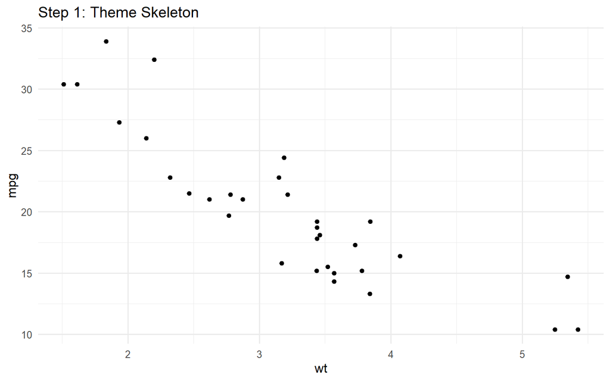

```r
# Step 1: Define the theme function
theme_custom <- function(base_size = 12, base_family = "") {
  # Start with a complete theme and replace everything
  theme_minimal(base_size = base_size, base_family = base_family) %+replace%
    theme(
      # We'll fill this in through the following steps
    )
}

# Test the skeleton
ggplot(mtcars, aes(wt, mpg)) +
  geom_point() +
  theme_custom() +
  labs(title = "Step 1: Theme Skeleton")
```

**Important:** Always start with `base_size` and `base_family` as parameters. This makes your theme reusable and scalable.

## 4.2 Step 2: Configure Plot and Panel Backgrounds

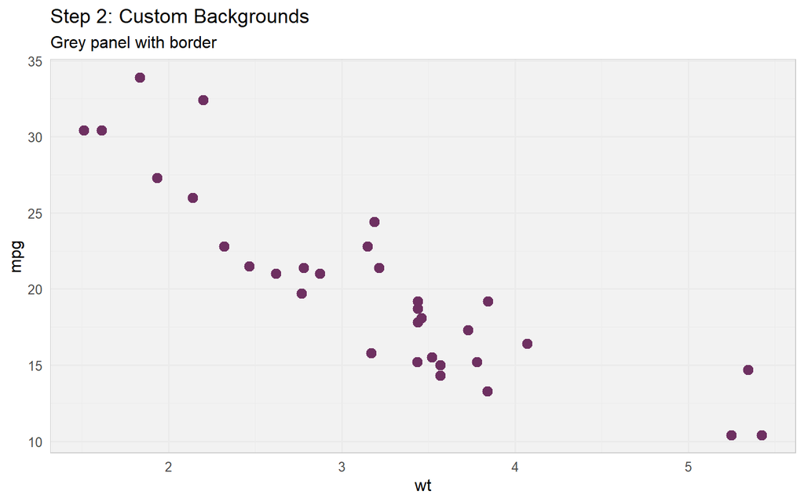

```r
theme_custom <- function(base_size = 12, base_family = "") {
  theme_minimal(base_size = base_size, base_family = base_family) %+replace%
    theme(
      # Plot background (behind everything)
      plot.background = element_rect(
        fill = "white",
        colour = NA,
        linewidth = 0
      ),
      # Panel background (the plotting area)
      panel.background = element_rect(
        fill = "grey95",
        colour = NA
      ),
      # Panel border
      panel.border = element_rect(
        fill = NA,
        colour = "grey80",
        linewidth = 0.5
      )
    )
}

# Test the backgrounds
ggplot(mtcars, aes(wt, mpg)) +
  geom_point(size = 3, colour = "#6E3061") +
  theme_custom() +
  labs(title = "Step 2: Custom Backgrounds",
       subtitle = "Grey panel with border")
```

## 4.3 Step 3: Define Grid Lines

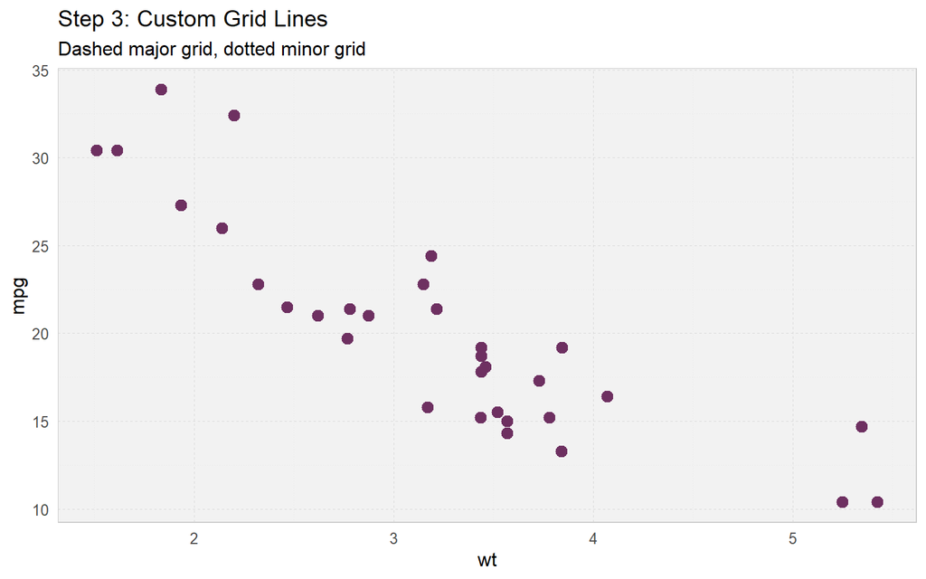

```r
theme_custom <- function(base_size = 12, base_family = "") {
  theme_minimal(base_size = base_size, base_family = base_family) %+replace%
    theme(
      plot.background = element_rect(fill = "white", colour = NA),
      panel.background = element_rect(fill = "grey95", colour = NA),
      panel.border = element_rect(fill = NA, colour = "grey80", linewidth = 0.5),

      # Major grid lines
      panel.grid.major = element_line(
        colour = "grey85",
        linewidth = 0.3,
        linetype = "dashed"
      ),
      # Minor grid lines
      panel.grid.minor = element_line(
        colour = "grey90",
        linewidth = 0.15,
        linetype = "dotted"
      )
    )
}

# Test grid lines
ggplot(mtcars, aes(wt, mpg)) +
  geom_point(size = 3, colour = "#6E3061") +
  theme_custom() +
  labs(title = "Step 3: Custom Grid Lines",
       subtitle = "Dashed major grid, dotted minor grid")
```

## 4.4 Step 4: Configure Axis Elements

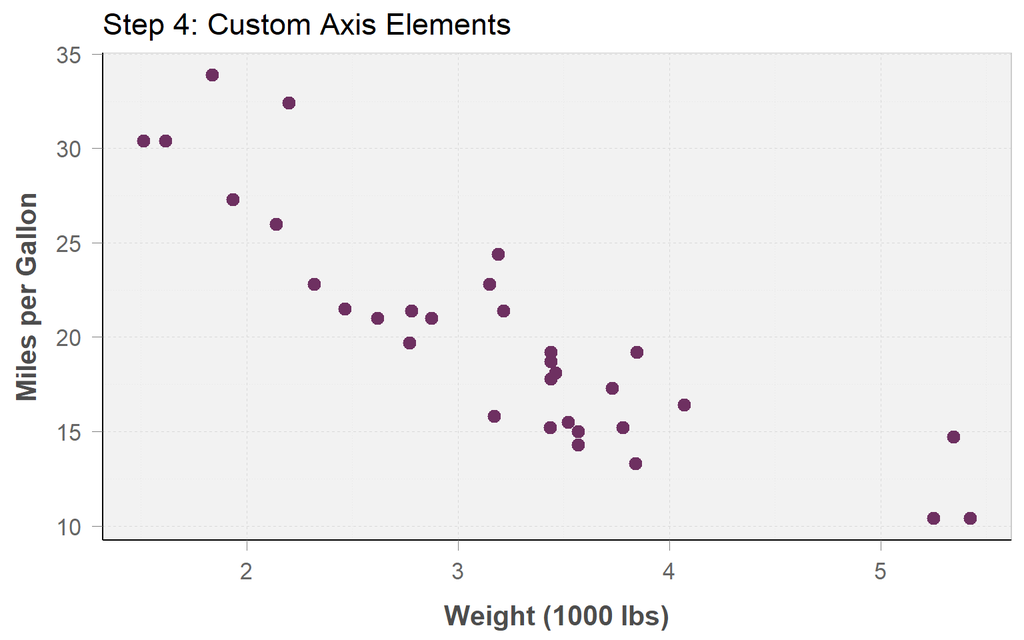

```r
theme_custom <- function(base_size = 12, base_family = "") {
  theme_minimal(base_size = base_size, base_family = base_family) %+replace%
    theme(
      plot.background = element_rect(fill = "white", colour = NA),
      panel.background = element_rect(fill = "grey95", colour = NA),
      panel.border = element_rect(fill = NA, colour = "grey80", linewidth = 0.5),
      panel.grid.major = element_line(colour = "grey85", linewidth = 0.3, linetype = "dashed"),
      panel.grid.minor = element_line(colour = "grey90", linewidth = 0.15, linetype = "dotted"),

      # Axis lines
      axis.line = element_line(colour = "black", linewidth = 0.5),
      # Axis ticks
      axis.ticks = element_line(colour = "grey50", linewidth = 0.3),
      axis.ticks.length = unit(2, "mm"),
      # Axis titles
      axis.title = element_text(
        size = rel(1.1),
        face = "bold",
        colour = "grey30"
      ),
      # Axis text (tick labels)
      axis.text = element_text(
        size = rel(0.9),
        colour = "grey40"
      ),
      # Individual axis title margins
      axis.title.x = element_text(margin = margin(t = 10)),
      axis.title.y = element_text(angle = 90, margin = margin(r = 10))
    )
}

# Test axis configuration
ggplot(mtcars, aes(wt, mpg)) +
  geom_point(size = 3, colour = "#6E3061") +
  theme_custom(base_size = 14) +
  labs(title = "Step 4: Custom Axis Elements",
       x = "Weight (1000 lbs)",
       y = "Miles per Gallon")
```

## 4.5 Step 5: Configure the Legend

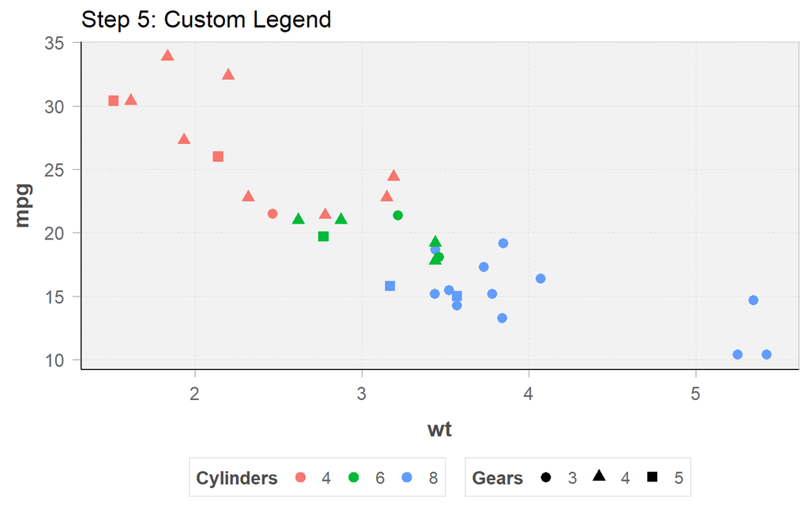

```r
theme_custom <- function(base_size = 12, base_family = "") {
  theme_minimal(base_size = base_size, base_family = base_family) %+replace%
    theme(
      plot.background = element_rect(fill = "white", colour = NA),
      panel.background = element_rect(fill = "grey95", colour = NA),
      panel.border = element_rect(fill = NA, colour = "grey80", linewidth = 0.5),
      panel.grid.major = element_line(colour = "grey85", linewidth = 0.3, linetype = "dashed"),
      panel.grid.minor = element_line(colour = "grey90", linewidth = 0.15, linetype = "dotted"),
      axis.line = element_line(colour = "black", linewidth = 0.5),
      axis.ticks = element_line(colour = "grey50", linewidth = 0.3),
      axis.ticks.length = unit(2, "mm"),
      axis.title = element_text(size = rel(1.1), face = "bold", colour = "grey30"),
      axis.text = element_text(size = rel(0.9), colour = "grey40"),
      axis.title.x = element_text(margin = margin(t = 10)),
      axis.title.y = element_text(angle = 90, margin = margin(r = 10)),

      # Legend background
      legend.background = element_rect(
        fill = "white",
        colour = "grey80",
        linewidth = 0.3
      ),
      # Legend title
      legend.title = element_text(
        size = rel(0.95),
        face = "bold",
        colour = "grey30"
      ),
      # Legend text
      legend.text = element_text(
        size = rel(0.85),
        colour = "grey40"
      ),
      # Legend key (the symbol area)
      legend.key = element_rect(
        fill = "white",
        colour = NA
      ),
      # Legend position and spacing
      legend.position = "bottom",
      legend.margin = margin(5, 5, 5, 5),
      legend.spacing = unit(5, "mm")
    )
}

# Test legend configuration
ggplot(mtcars, aes(wt, mpg, colour = factor(cyl), shape = factor(gear))) +
  geom_point(size = 3) +
  theme_custom(base_size = 14) +
  labs(title = "Step 5: Custom Legend",
       colour = "Cylinders",
       shape = "Gears")
```

## 4.6 Step 6: Define Plot Titles and Labels

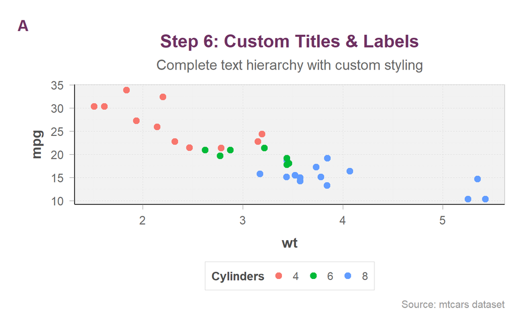

```r
theme_custom <- function(base_size = 12, base_family = "") {
  theme_minimal(base_size = base_size, base_family = base_family) %+replace%
    theme(
      # Previous steps...
      plot.background = element_rect(fill = "white", colour = NA),
      panel.background = element_rect(fill = "grey95", colour = NA),
      panel.border = element_rect(fill = NA, colour = "grey80", linewidth = 0.5),
      panel.grid.major = element_line(colour = "grey85", linewidth = 0.3, linetype = "dashed"),
      panel.grid.minor = element_line(colour = "grey90", linewidth = 0.15, linetype = "dotted"),
      axis.line = element_line(colour = "black", linewidth = 0.5),
      axis.ticks = element_line(colour = "grey50", linewidth = 0.3),
      axis.ticks.length = unit(2, "mm"),
      axis.title = element_text(size = rel(1.1), face = "bold", colour = "grey30"),
      axis.text = element_text(size = rel(0.9), colour = "grey40"),
      axis.title.x = element_text(margin = margin(t = 10)),
      axis.title.y = element_text(angle = 90, margin = margin(r = 10)),
      legend.background = element_rect(fill = "white", colour = "grey80", linewidth = 0.3),
      legend.title = element_text(size = rel(0.95), face = "bold", colour = "grey30"),
      legend.text = element_text(size = rel(0.85), colour = "grey40"),
      legend.key = element_rect(fill = "white", colour = NA),
      legend.position = "bottom",

      # Plot title
      plot.title = element_text(
        size = rel(1.4),
        face = "bold",
        colour = "#6E3061",
        hjust = 0.5,
        margin = margin(b = 10)
      ),
      # Subtitle
      plot.subtitle = element_text(
        size = rel(1.1),
        colour = "grey40",
        hjust = 0.5,
        margin = margin(b = 15)
      ),
      # Caption
      plot.caption = element_text(
        size = rel(0.8),
        colour = "grey60",
        hjust = 1,
        margin = margin(t = 10)
      ),
      # Tag (for labeling subplots)
      plot.tag = element_text(
        size = rel(1.2),
        face = "bold",
        colour = "#6E3061"
      ),
      # Overall plot margins
      plot.margin = margin(20, 20, 20, 20)
    )
}

# Test title configuration
ggplot(mtcars, aes(wt, mpg, colour = factor(cyl))) +
  geom_point(size = 3) +
  theme_custom(base_size = 14) +
  labs(
    title = "Step 6: Custom Titles & Labels",
    subtitle = "Complete text hierarchy with custom styling",
    caption = "Source: mtcars dataset",
    colour = "Cylinders",
    tag = "A"
  )
```

## 4.7 Step 7: Configure Facet Strips

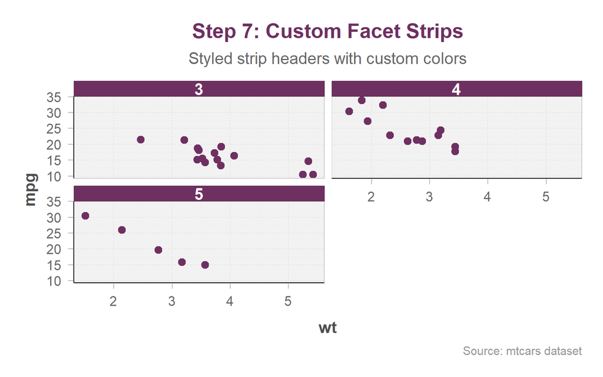

```r
theme_custom <- function(base_size = 12, base_family = "") {
  theme_minimal(base_size = base_size, base_family = base_family) %+replace%
    theme(
      # All previous steps...
      plot.background = element_rect(fill = "white", colour = NA),
      panel.background = element_rect(fill = "grey95", colour = NA),
      panel.border = element_rect(fill = NA, colour = "grey80", linewidth = 0.5),
      panel.grid.major = element_line(colour = "grey85", linewidth = 0.3, linetype = "dashed"),
      panel.grid.minor = element_line(colour = "grey90", linewidth = 0.15, linetype = "dotted"),
      axis.line = element_line(colour = "black", linewidth = 0.5),
      axis.ticks = element_line(colour = "grey50", linewidth = 0.3),
      axis.ticks.length = unit(2, "mm"),
      axis.title = element_text(size = rel(1.1), face = "bold", colour = "grey30"),
      axis.text = element_text(size = rel(0.9), colour = "grey40"),
      axis.title.x = element_text(margin = margin(t = 10)),
      axis.title.y = element_text(angle = 90, margin = margin(r = 10)),
      legend.background = element_rect(fill = "white", colour = "grey80", linewidth = 0.3),
      legend.title = element_text(size = rel(0.95), face = "bold", colour = "grey30"),
      legend.text = element_text(size = rel(0.85), colour = "grey40"),
      legend.key = element_rect(fill = "white", colour = NA),
      legend.position = "bottom",
      plot.title = element_text(size = rel(1.4), face = "bold", colour = "#6E3061", hjust = 0.5, margin = margin(b = 10)),
      plot.subtitle = element_text(size = rel(1.1), colour = "grey40", hjust = 0.5, margin = margin(b = 15)),
      plot.caption = element_text(size = rel(0.8), colour = "grey60", hjust = 1, margin = margin(t = 10)),
      plot.tag = element_text(size = rel(1.2), face = "bold", colour = "#6E3061"),
      plot.margin = margin(20, 20, 20, 20),

      # Strip background (facet headers)
      strip.background = element_rect(
        fill = "#6E3061",
        colour = "#4a2040",
        linewidth = 0.3
      ),
      # Strip text
      strip.text = element_text(
        size = rel(1.1),
        face = "bold",
        colour = "white"
      ),
      # Strip placement
      strip.placement = "outside"
    )
}

# Test facet configuration
ggplot(mtcars, aes(wt, mpg)) +
  geom_point(size = 3, colour = "#6E3061") +
  facet_wrap(~ gear, nrow = 2) +
  theme_custom(base_size = 14) +
  labs(
    title = "Step 7: Custom Facet Strips",
    subtitle = "Styled strip headers with custom colors",
    caption = "Source: mtcars dataset"
  )
```

## 4.8 Putting It All Together: A Complete Theme Example

```r
theme_master_demo <- function(base_size = 14, base_family = "") {
  theme_minimal(base_size = base_size, base_family = base_family) %+replace%
    theme(
      # === element_rect() usage ===
      plot.background = element_rect(
        fill = "#fdfafd",
        colour = NA
      ),
      panel.background = element_rect(
        fill = "white",
        colour = NA
      ),
      panel.border = element_rect(
        fill = NA,
        colour = "#6E3061",
        linewidth = 0.8
      ),
      legend.background = element_rect(
        fill = "white",
        colour = "#d4c0d1",
        linewidth = 0.3
      ),
      legend.key = element_rect(
        fill = "white",
        colour = NA
      ),
      strip.background = element_rect(
        fill = "#6E3061",
        colour = "#4a2040",
        linewidth = 0.3
      ),

      # === element_line() usage ===
      panel.grid.major = element_line(
        colour = "grey90",
        linewidth = 0.3,
        linetype = "solid"
      ),
      panel.grid.minor = element_line(
        colour = "grey95",
        linewidth = 0.15,
        linetype = "dotted"
      ),
      axis.line = element_line(
        colour = "#6E3061",
        linewidth = 0.6
      ),
      axis.ticks = element_line(
        colour = "grey60",
        linewidth = 0.4
      ),

      # === element_text() usage ===
      plot.title = element_text(
        family = base_family,
        face = "bold",
        colour = "#6E3061",
        size = rel(1.4),
        hjust = 0.5,
        margin = margin(b = 12)
      ),
      plot.subtitle = element_text(
        colour = "grey40",
        size = rel(1.1),
        hjust = 0.5,
        margin = margin(b = 15)
      ),
      plot.caption = element_text(
        colour = "grey50",
        size = rel(0.8),
        hjust = 1,
        margin = margin(t = 12)
      ),
      plot.tag = element_text(
        face = "bold",
        colour = "#6E3061",
        size = rel(1.2)
      ),
      axis.title = element_text(
        face = "bold",
        colour = "grey30",
        size = rel(1.05)
      ),
      axis.text = element_text(
        colour = "grey40",
        size = rel(0.9)
      ),
      legend.title = element_text(
        face = "bold",
        colour = "grey30",
        size = rel(0.95)
      ),
      legend.text = element_text(
        colour = "grey40",
        size = rel(0.85)
      ),
      strip.text = element_text(
        face = "bold",
        colour = "white",
        size = rel(1.1)
      ),

      # === element_blank() usage ===
      # (we keep these, but they would be element_blank() if removed)

      # === Spacing ===
      axis.ticks.length = unit(2.5, "mm"),
      legend.position = "bottom",
      legend.margin = margin(8, 8, 8, 8),
      plot.margin = margin(20, 20, 20, 20),
      strip.placement = "outside"
    )
}
```

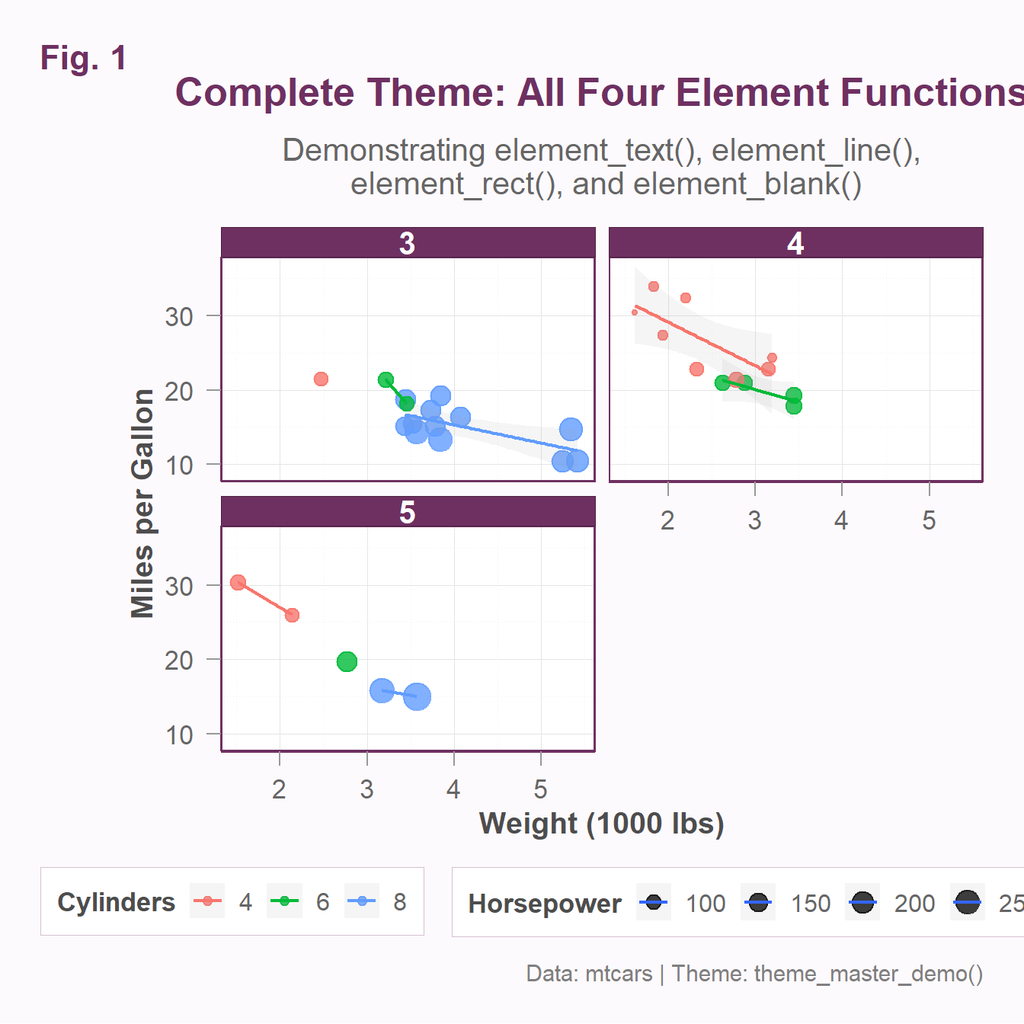

```r
# Apply the complete theme to a comprehensive plot
ggplot(mtcars, aes(wt, mpg, colour = factor(cyl), size = hp)) +
  geom_point(alpha = 0.8) +
  geom_smooth(method = "lm", se = TRUE, alpha = 0.1, linewidth = 0.8) +
  facet_wrap(~ gear, nrow = 2) +
  theme_master_demo(base_size = 14) +
  labs(
    title = "Complete Theme: All Four Element Functions",
    subtitle = "Demonstrating element_text(), element_line(),\n element_rect(), and element_blank()",
    caption = "Data: mtcars | Theme: theme_master_demo()",
    x = "Weight (1000 lbs)",
    y = "Miles per Gallon",
    colour = "Cylinders",
    size = "Horsepower",
    tag = "Fig. 1"
  )
```

# 5 Complete Custom Theme Examples

Recall that the primary purpose of `theme()` is to separate data representation from stylistic decoration, ensuring that visual clutter does not distract from the underlying insights. It enables consistency across multiple plots, supports branding or journal formatting, and adheres to principles like maximizing the data-ink ratio by removing unnecessary grid lines or backgrounds. Ultimately, mastering `theme()` empowers you to transform a default ggplot into a clear, professional, and customized visualization that effectively communicates your data’s story.

This section offers a few complete examples for different purposes.

## 5.1 Publication-Ready Theme

Because different journals require different visual styles, `theme()` enables you to generate plots that are consistent with the specific formatting requirements of each publication.

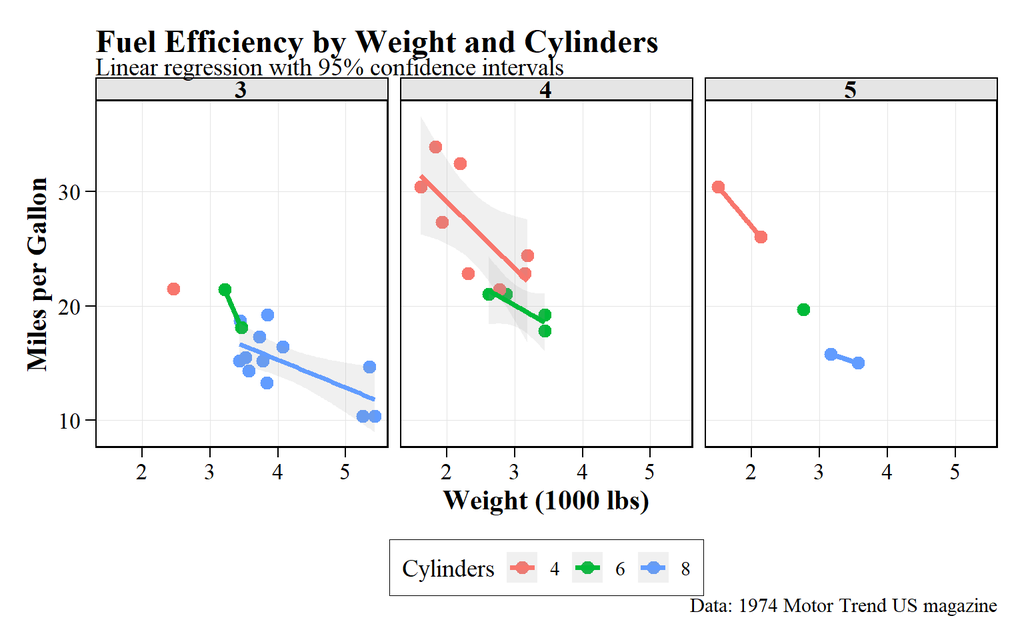

```r
theme_publication <- function(base_size = 14, base_family = "serif") {
  theme_bw(base_size = base_size, base_family = base_family) %+replace%
    theme(
      # Clean background
      panel.background = element_rect(fill = "white"),
      panel.border = element_rect(fill = NA, colour = "black", linewidth = 0.8),
      panel.grid.major = element_line(colour = "grey90", linewidth = 0.2),
      panel.grid.minor = element_blank(),

      # Axis formatting
      axis.line = element_blank(),
      axis.ticks = element_line(colour = "black", linewidth = 0.5),
      axis.ticks.length = unit(2, "mm"),
      axis.text = element_text(size = rel(0.9), colour = "black"),
      axis.title = element_text(size = rel(1.1), face = "bold"),

      # Legend
      legend.background = element_rect(fill = "white", colour = "black", linewidth = 0.3),
      legend.key = element_rect(fill = "white", colour = NA),
      legend.position = "bottom",

      # Titles
      plot.title = element_text(size = rel(1.3), face = "bold", hjust = 0),
      plot.subtitle = element_text(size = rel(1), hjust = 0),
      plot.caption = element_text(size = rel(0.8), hjust = 1),
      plot.margin = margin(15, 15, 15, 15),

      # Strips
      strip.background = element_rect(fill = "grey90", colour = "black"),
      strip.text = element_text(size = rel(1), face = "bold")
    )
}

# Demonstrate publication theme
ggplot(mtcars, aes(wt, mpg, colour = factor(cyl))) +
  geom_point(size = 3) +
  geom_smooth(method = "lm", se = TRUE, alpha = 0.15) +
  facet_wrap(~ gear) +
  theme_publication(base_size = 14, base_family = "serif") +
  labs(
    title = "Fuel Efficiency by Weight and Cylinders",
    subtitle = "Linear regression with 95% confidence intervals",
    caption = "Data: 1974 Motor Trend US magazine",
    x = "Weight (1000 lbs)",
    y = "Miles per Gallon",
    colour = "Cylinders"
  )
```

**Publication Tip:** Always use

```
base_family =
“serif”
```

for academic publications. Most journals prefer serif fonts. Set `base_size = 14` or higher for readability.

## 5.2 Dashboard Minimal Theme

Dashboard environments demand visual clarity and fast interpretation. Unlike publication-ready plots that may tolerate decorative elements, dashboards benefit from a restrained, minimalist approach. The Dashboard Minimal Theme strips away unnecessary chart junk—including background fills, minor grid lines, and excess borders—to focus entirely on the data. This clean aesthetic reduces cognitive load, ensures consistency across multiple panels, and allows end users to extract insights at a glance, making it the optimal choice for interactive and real-time dashboards.

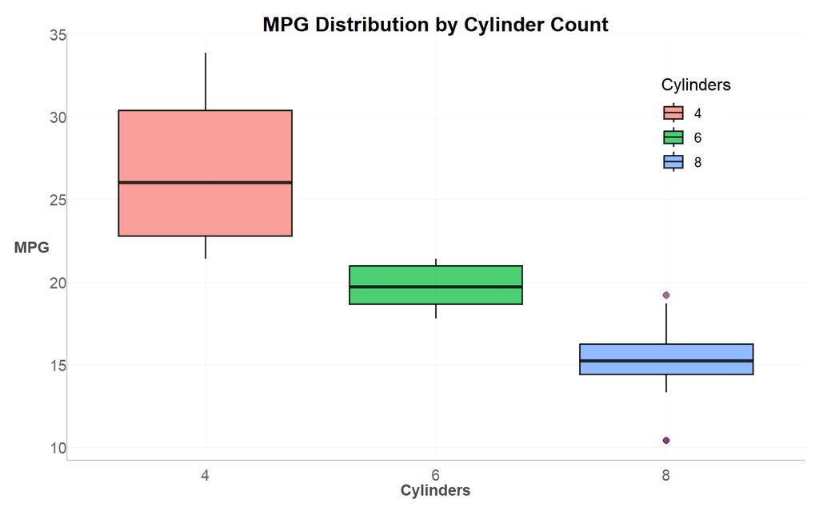

```r
theme_dashboard <- function(base_size = 12, base_family = "") {
  theme_void(base_size = base_size, base_family = base_family) %+replace%
    theme(
      # Minimal grid
      panel.grid.major = element_line(colour = "grey95", linewidth = 0.2),
      panel.grid.minor = element_blank(),

      # Simple axis lines
      axis.line = element_line(colour = "grey60", linewidth = 0.3),
      axis.ticks = element_line(colour = "grey60", linewidth = 0.3),
      axis.text = element_text(size = rel(0.9), colour = "grey40", margin = margin(5)),
      axis.title = element_text(size = rel(0.9), face = "bold", colour = "grey30"),

      # Floating legend
      legend.position = c(0.9, 0.9),
      legend.justification = c(1, 1),
      legend.background = element_rect(fill = alpha("white", 0.8), colour = NA),
      legend.key = element_blank(),

      # Compact titles
      plot.title = element_text(size = rel(1.2), face = "bold", hjust = 0.5),
      plot.margin = margin(10, 10, 10, 10)
    )
}

# Demonstrate dashboard theme
ggplot(mtcars, aes(factor(cyl), mpg, fill = factor(cyl))) +
  geom_boxplot(alpha = 0.7, outlier.colour = "#6E3061", outlier.size = 2) +
  theme_dashboard(base_size = 12) +
  labs(
    title = "MPG Distribution by Cylinder Count",
    x = "Cylinders",
    y = "MPG",
    fill = "Cylinders"
  ) #+
```

```r
 # scale_fill_brewer
```

**Dashboard Tip:** Use `theme_void()` as the base for maximum control. Floating legends save space. Keep margins compact for dashboard layouts.

## 5.3 Dark Presentation Theme

A well-built plot answers a question, but a well-themed plot commands attention and credibility. The “presentation theme” in ggplot2 encompasses all stylistic choices that are independent of the underlying data—from panel backgrounds and grid lines to legend placement and title fonts. Mastering the `theme()` function allows you to adapt any graphic for its final medium, ensuring consistency across a report, adherence to journal guidelines, or alignment with a brand’s visual identity.

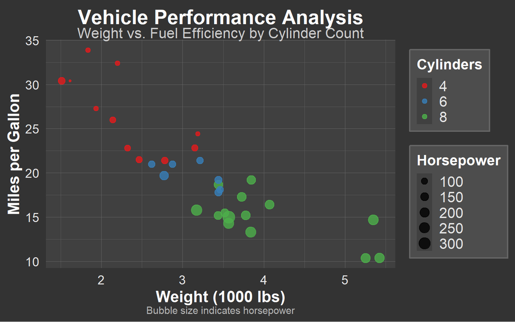

```r
theme_dark_presentation <- function(base_size = 16, base_family = "") {
  theme_minimal(base_size = base_size, base_family = base_family) %+replace%
    theme(
      # Dark background
      plot.background = element_rect(fill = "grey20", colour = NA),
      panel.background = element_rect(fill = "grey25", colour = NA),

      # Grid lines visible on dark
      panel.grid.major = element_line(colour = "grey40", linewidth = 0.3),
      panel.grid.minor = element_line(colour = "grey35", linewidth = 0.15),

      # Light text for contrast
      axis.text = element_text(colour = "grey90", size = rel(0.9)),
      axis.title = element_text(colour = "white", size = rel(1.1), face = "bold"),
      plot.title = element_text(colour = "white", size = rel(1.4), face = "bold", hjust = 0.5),
      plot.subtitle = element_text(colour = "grey80", size = rel(1), hjust = 0.5),
      plot.caption = element_text(colour = "grey70", size = rel(0.7)),

      # Legend on dark
      legend.text = element_text(colour = "grey90"),
      legend.title = element_text(colour = "white", face = "bold"),
      legend.background = element_rect(fill = "grey30", colour = "grey40"),
      legend.key = element_rect(fill = "grey25", colour = NA),

      # Strip formatting
      strip.background = element_rect(fill = "grey40", colour = "grey50"),
      strip.text = element_text(colour = "white", face = "bold")
    )
}

# Demonstrate dark theme
ggplot(mtcars, aes(wt, mpg, colour = factor(cyl), size = hp)) +
  geom_point(alpha = 0.8) +
  theme_dark_presentation(base_size = 16) +
  labs(
    title = "Vehicle Performance Analysis",
    subtitle = "Weight vs. Fuel Efficiency by Cylinder Count",
    caption = "Bubble size indicates horsepower",
    x = "Weight (1000 lbs)",
    y = "Miles per Gallon",
    colour = "Cylinders",
    size = "Horsepower"
  ) +
  scale_colour_brewer(palette = "Set1")
```

**Accessibility Note:** Ensure sufficient color contrast in dark themes. Use [WebAIM’s Contrast Checker](https://webaim.org/resources/contrastchecker/) to verify WCAG 2.1 AA compliance (4.5:1 for normal text, 3:1 for large text).